# Harry Potter And Half-Blood Prince

Weiqi Pan

November 4, 2017

## Background

Harry Potter is a series of fantasy novels written by British author J. K. Rowling. The novels chronicle the life of a young wizard, Harry Potter, and his friends Hermione Granger and Ron Weasley, all of whom are students at Hogwarts School of Witchcraft and Wizardry. The main story arc concerns Harry’s struggle against Lord Voldemort, a dark wizard who intends to become immortal, overthrow the wizard governing body known as the Ministry of Magic, and subjugate all wizards and muggles, a reference term that means non-magical people.

This is just a simple report on some of the basic statistics for the 6th book in the series, Harry Potter and the Half-Blood Prince.

## The Data

The data used in this report is from the R package, Harry Potter Book Series.

## Basic Information

1. The graph below depicts the most important 100 keywords in Harry Potter and The Half-Blood Prince. By knowking the keywords in this book, we can have a basic idea of the content of this book and the relatively important words.

[figure not shown]

*Fig. 1* Keywords in Half-Blood Prince

2. Harry Potter and Half-Blood Prince has a total of 171,284 words. The table below displays the most common words in each chapter. By knowing that, we can have a basic idea of the important charcaters or items in each chapter in order to get to know the story frame.

| chapter | word | n |
| --- | --- | --- |
| 1 | prime | 98 |
| 2 | dark | 58 |
| 3 | harry | 59 |
| 4 | harry | 94 |
| 5 | harry | 84 |
| 6 | harry | 83 |
| 7 | harry | 118 |
| 8 | harry | 73 |
| 9 | harry | 80 |
| 10 | harry | 76 |
| 11 | harry | 82 |
| 12 | harry | 106 |
| 13 | dumbledore | 95 |
| 14 | harry | 125 |
| 15 | harry | 95 |
| 16 | harry | 105 |
| 17 | harry | 91 |
| 18 | harry | 145 |
| 19 | harry | 113 |
| 20 | harry | 80 |
| 21 | harry | 94 |
| 22 | harry | 115 |
| 23 | harry | 86 |
| 24 | harry | 106 |
| 25 | harry | 110 |
| 26 | harry | 142 |
| 27 | dumbledore | 82 |
| 28 | harry | 77 |
| 29 | harry | 62 |
| 30 | harry | 90 |

3. There are many characters in this book. And the graph below depicts the main characters and their frequencies in this book.

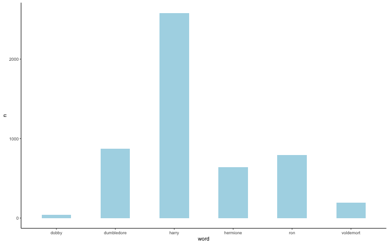

*Fig. 2* Main Characters

## More Analysis

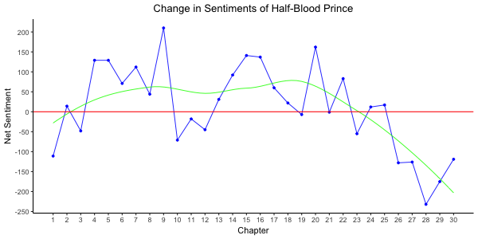

*Fig. 3* Sentiment Change in Half-Blood Prince

5. Among all the emotions, we can try to analyze the change of one specific emotion “anticipation”.

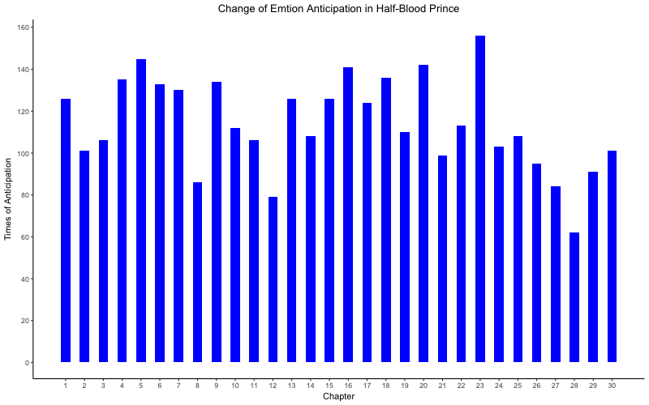

6. To make further analysis, we can try to examine bigrams in this book. After cleaning the data, the following table gives the most popular bigrams in each chapter. From the table, we can see the most important keywords in every chapter in order to know the story outline.

| chapter | bigram | n |
| --- | --- | --- |
| 1 | prime minister | 88 |
| 2 | dark lord | 41 |
| 3 | uncle vernon | 19 |
| 4 | death eaters | 7 |
| 5 | dark arts | 6 |
| 6 | harry ron | 8 |
| 7 | luggage rack | 6 |
| 8 | invisibility cloak | 5 |
| 9 | professor mcgonagall | 10 |
| 10 | tom riddle | 5 |
| 11 | staff table | 4 |
| 12 | professor mcgonagall | 14 |
| 13 | tom riddle | 6 |
| 14 | gryffindor team | 4 |
| 14 | pumpkin juice | 4 |
| 15 | professor trelawney | 8 |
| 16 | half blood | 4 |
| 16 | scrim geour | 4 |
| 17 | professor slughorn | 4 |
| 17 | tom riddle | 4 |
| 18 | chocolate cauldrons | 5 |
| 19 | madam pomfrey | 11 |
| 20 | house elf | 9 |
| 21 | harry potter | 7 |
| 22 | felix felicis | 7 |
| 23 | lord voldemort | 9 |
| 24 | advanced potion | 6 |
| 24 | moaning myrtle | 6 |
| 25 | professor trelawney | 16 |
| 26 | black water | 5 |
| 26 | dark water | 5 |
| 26 | dumbledore drank | 5 |
| 26 | dumbledore raised | 5 |
| 26 | harry looked | 5 |
| 26 | lord voldemort | 5 |
| 27 | death eaters | 8 |
| 28 | death eater | 11 |
| 29 | professor mcgonagall | 25 |
| 30 | dumbledore’s body | 6 |